# Stroop Effect

1. In the Stroop Task, subjects are timed and asked to read different sets of congruently and inconguently colored words. The dependent variable is the time it takes to corectly complete each list of words, as it is dependent on which set the subject reads. The Independent variable is the color of the words, congruent or incongruent.

2. The data collected for our hypothesis and test are from 24 subjects that we assume is random. We know our subjects are a sample of the population and that the population parameters are unknown. I chose to use a dependent negative one tailed T-test with an alpha level of α = .05. The data is numerical and this test will compare the mean of one set of data to the mean of another for the same subjects. The null hypothesis, H<sub>0</sub>, that I chose will infer that the populations mean time for congruent colored words is equal to or greater than the population mean time for incongruent colored words. Shown here as H<sub>0</sub>: μ<sub>c</sub> ≥ μ<sub>i</sub>. The alternative hypothesis, H<sub>A</sub>, will therefore be that the population mean time for congruent colored words will be significantly lower than the population mean time for incongruent colored words. Shown here as H<sub>A</sub>: μ<sub>c</sub> < μ<sub>i</sub>. I believe that it will have an effect, slowing down the reaction times of the subjects.

2. (Continued) H<sub>0</sub> will stand for the null hypothesis, H<sub>A</sub> will stand for the alternative hypothesis. μ<sub>c</sub> and μ<sub>i</sub> will stand for the population mean time for congruent colored words and incongruent colored words respectivly. We are making several assumptions about the data. That it is randomly sampled data from a population that is normally distributed and the samples are linked to the population.

3. This is the data we were given to test.

```python
import pandas as pd
import math as mt
import matplotlib.pyplot as plt

filename = "stroopdata.csv"

stsample = pd.read_csv(filename)
stsample[["Congruent", "Incongruent"]]
```

|  | Congruent | Incongruent |
| --- | --- | --- |
| 0 | 12.079 | 19.278 |
| 1 | 16.791 | 18.741 |
| 2 | 9.564 | 21.214 |
| 3 | 8.630 | 15.687 |
| 4 | 14.669 | 22.803 |
| 5 | 12.238 | 20.878 |
| 6 | 14.692 | 24.572 |
| 7 | 8.987 | 17.394 |
| 8 | 9.401 | 20.762 |
| 9 | 14.480 | 26.282 |
| 10 | 22.328 | 24.524 |
| 11 | 15.298 | 18.644 |
| 12 | 15.073 | 17.510 |
| 13 | 16.929 | 20.330 |
| 14 | 18.200 | 35.255 |
| 15 | 12.130 | 22.158 |
| 16 | 18.495 | 25.139 |
| 17 | 10.639 | 20.429 |
| 18 | 11.344 | 17.425 |
| 19 | 12.369 | 34.288 |
| 20 | 12.944 | 23.894 |
| 21 | 14.233 | 17.960 |
| 22 | 19.710 | 22.058 |
| 23 | 16.004 | 21.157 |

3. (Continued) Here is some basic statistical information about the data.

```python
stsample[["Congruent", "Incongruent"]].describe()
```

|  | Congruent | Incongruent |
| --- | --- | --- |
| count | 24.000000 | 24.000000 |
| mean | 14.051125 | 22.015917 |
| std | 3.559358 | 4.797057 |
| min | 8.630000 | 15.687000 |
| 25% | 11.895250 | 18.716750 |
| 50% | 14.356500 | 21.017500 |
| 75% | 16.200750 | 24.051500 |
| max | 22.328000 | 35.255000 |

3. (Continued) It looks as if there was indeed some delay in the incongruent times. The difference also looks to be significant, but we need to test it to be sure.

4. This is a graph of the data made to show the difference in times for each subject.

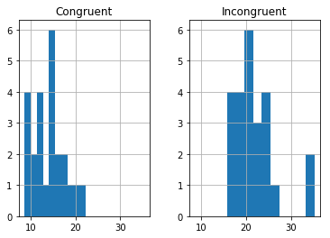

```python
stsample[["Congruent", "Incongruent"]].hist(sharex=True,)
plt.show()
```

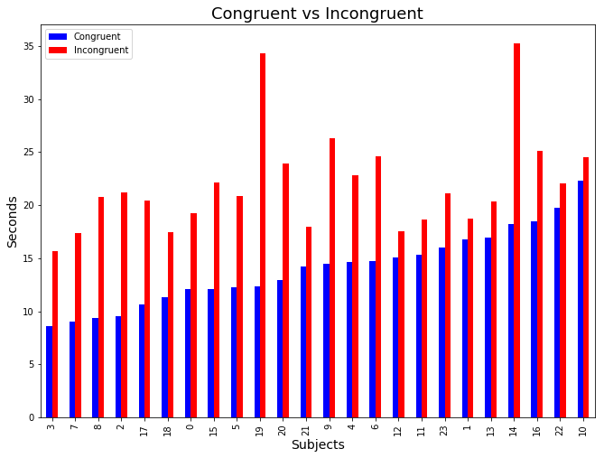

```python
samplepx = stsample[["Congruent", "Incongruent"]].sort_values(by='Congruent').plot( kind='bar',
                      figsize=(11, 8), color=['b', 'r'],
                      sharex=True, sharey=True)
samplepx.set_title('Congruent vs Incongruent', fontsize='18')
samplepx.set_ylabel('Seconds', fontsize='14')
samplepx.set_xlabel('Subjects', fontsize='14')
plt.show()
```

4. (Continued) Again you can see that evernyone had slower times with the incongruent words. People with slower congruent times appear to see less effect on their incongruent times. While those with short congruent times appear to see a much larger effect.

5.To start our T-test, here is our important info and below is our formulas and work. Useful info is x̄<sub>c</sub>(congruent mean) = 14.05, x̄<sub>i</sub>(incongruent mean) = 22.02, degrees of freedom = 23, n(number of subjects) = 24. This means our T<sub>crit</sub> = -1.714.

```python
xbar1 = 14.05
xbar2 = 22.02
n = 24
sumofsquares = stsample["Squared Diff"].sum()
variance = sumofsquares/(n - 1)
stddev = mt.sqrt(variance)
degreesfreedom = (n - 1)
meandiff = xbar1 - xbar2
tcrit = -1.714

sampleerror = stddev/mt.sqrt(n)
t = meandiff/sampleerror


print "T Critical =", tcrit
print "T =", t
```

```
T Critical = -1.714
T = -8.02594777909
```

With a T score of -8.03, we are well below our T<sub>crit</sub> value of -1.714. Thus we reject the null hypothesis and accept the alternte hypothesis. Incongruent word colors has a significant effect on the time it takes to say the color corectly. Now lets find a couple measures of effect, Cohen's D and r².

```python
cohend = meandiff/stddev
rsquared = (t * t)/((t * t) + degreesfreedom)

print "Cohen's D =", cohend
print "r^2 =", rsquared
```

```
Cohen's D = -1.63828973008
r^2 = 0.736889783461
```

6.What is behind the slower times for incongruent words? I think it could be many things acting together instead of a single effect on our abilities. Perhaps the brain reads the word in a single instance before moving on to color, which might also process at different speeds creating delays before speaking the correct answer. Other tests might include something along the line of what you see versus what you smell. I'm not sure which way that would go. Saying what you smell first or what you see?